# Report of exercise 4

Finally, the bonus exercise: clustering with k-means and then performing LDA for the resulted clusters. I run k-means with 4 clusters and save the clusters as their own column in the new_boston dataframe. Then i fit the LDA model for these clusters.

```r
data(Boston)
summary(new_boston)
```

```
##       crim                 zn               indus              chas
##  Min.   :-0.419367   Min.   :-0.48724   Min.   :-1.5563   Min.   :-0.2723
##  1st Qu.:-0.410563   1st Qu.:-0.48724   1st Qu.:-0.8668   1st Qu.:-0.2723
##  Median :-0.390280   Median :-0.48724   Median :-0.2109   Median :-0.2723
##  Mean   : 0.000000   Mean   : 0.00000   Mean   : 0.0000   Mean   : 0.0000
##  3rd Qu.: 0.007389   3rd Qu.: 0.04872   3rd Qu.: 1.0150   3rd Qu.:-0.2723
##  Max.   : 9.924110   Max.   : 3.80047   Max.   : 2.4202   Max.   : 3.6648
##       nox                rm               age               dis
##  Min.   :-1.4644   Min.   :-3.8764   Min.   :-2.3331   Min.   :-1.2658
##  1st Qu.:-0.9121   1st Qu.:-0.5681   1st Qu.:-0.8366   1st Qu.:-0.8049
##  Median :-0.1441   Median :-0.1084   Median : 0.3171   Median :-0.2790
##  Mean   : 0.0000   Mean   : 0.0000   Mean   : 0.0000   Mean   : 0.0000
##  3rd Qu.: 0.5981   3rd Qu.: 0.4823   3rd Qu.: 0.9059   3rd Qu.: 0.6617
##  Max.   : 2.7296   Max.   : 3.5515   Max.   : 1.1164   Max.   : 3.9566
##       rad               tax             ptratio            black
##  Min.   :-0.9819   Min.   :-1.3127   Min.   :-2.7047   Min.   :-3.9033
##  1st Qu.:-0.6373   1st Qu.:-0.7668   1st Qu.:-0.4876   1st Qu.: 0.2049
##  Median :-0.5225   Median :-0.4642   Median : 0.2746   Median : 0.3808
##  Mean   : 0.0000   Mean   : 0.0000   Mean   : 0.0000   Mean   : 0.0000
##  3rd Qu.: 1.6596   3rd Qu.: 1.5294   3rd Qu.: 0.8058   3rd Qu.: 0.4332
##  Max.   : 1.6596   Max.   : 1.7964   Max.   : 1.6372   Max.   : 0.4406
##      lstat              medv
##  Min.   :-1.5296   Min.   :-1.9063
##  1st Qu.:-0.7986   1st Qu.:-0.5989
##  Median :-0.1811   Median :-0.1449
##  Mean   : 0.0000   Mean   : 0.0000
##  3rd Qu.: 0.6024   3rd Qu.: 0.2683
##  Max.   : 3.5453   Max.   : 2.9865
```

```r
set.seed(123)
km <-kmeans(new_boston, centers = 4)
new_boston$cluster_num <- as.factor(km$cluster)
summary(new_boston$cluster_num)
```

```
##   1   2   3   4
##  42 127 125 212
```

```r
lda.fit.new <- lda(cluster_num~., data = new_boston)
lda.fit.new
```

```
## Call:
## lda(cluster_num ~ ., data = new_boston)
##
## Prior probabilities of groups:
##          1          2          3          4
## 0.08300395 0.25098814 0.24703557 0.41897233
##
## Group means:
##        crim         zn      indus         chas        nox         rm
## 1  1.916757 -0.4872402  1.0201311 -0.272329068  1.0484799 -0.4122561
## 2  0.392245 -0.4872402  1.1697122  0.099680403  1.1439383 -0.4650169
## 3 -0.398970  1.2614609 -0.9791535 -0.020354653 -0.8573235  1.0090468
## 4 -0.379470 -0.3553728 -0.3254942  0.006239345 -0.3875041 -0.2347120
##           age        dis        rad        tax      ptratio      black
## 1  0.78947129 -0.8908848  1.6076484  1.4922585  0.745290819 -2.8449572
## 2  0.80978018 -0.8411778  1.0202595  1.1728009  0.554458254  0.1236280
## 3 -0.96130713  0.9497716 -0.5867985 -0.6709807 -0.802391366  0.3552363
## 4 -0.07470041  0.1204023 -0.5836998 -0.6025848 -0.006695716  0.2801081
##        lstat       medv
## 1  1.2421501 -1.1216726
## 2  0.7233656 -0.5227308
## 3 -0.9571271  1.0666829
## 4 -0.1150795 -0.0935769
##
## Coefficients of linear discriminants:
##                  LD1         LD2         LD3
## crim    -0.286023125  0.80602402 -0.03333291
## zn      -0.089859575  0.13462263 -1.10231465
## indus   -0.735653415 -0.45789839 -0.28208393
## chas     0.017410931 -0.05012732  0.10429028
## nox     -0.899932933 -0.62685584 -0.88920386
## rm       0.097896063  0.23979626 -0.55810591
## age      0.109881276 -0.12193217  0.43714910
## dis     -0.003570884 -0.07345087 -0.37105427
## rad     -0.556638804 -0.13777523 -0.06560018
## tax     -0.784022250 -0.48969815 -0.63992730
## ptratio -0.345404084 -0.09075010 -0.08271930
## black    0.763101368 -1.86649503 -0.36582132
## lstat   -0.200448270  0.09690647 -0.40471029
## medv     0.054565330  0.12584075 -0.79189479
##
## Proportion of trace:
##    LD1    LD2    LD3
## 0.7012 0.1963 0.1025
```

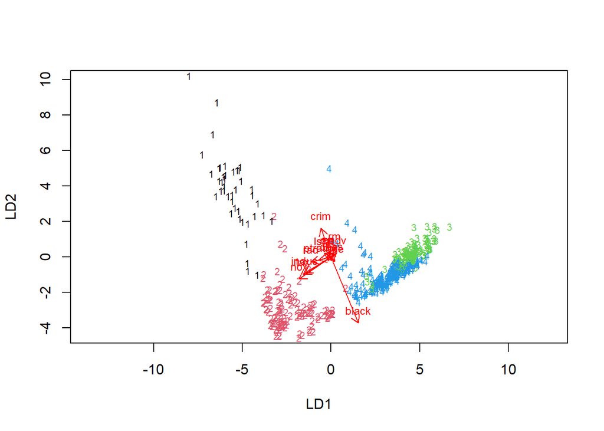

```r
lda.arrows <- function(x, myscale = 1, arrow_heads = 0.1, color = "red", tex = 0.75, choices = c(1,2)){
  heads <- coef(x)
  arrows(x0 = 0, y0 = 0,
         x1 = myscale * heads[,choices[1]],
         y1 = myscale * heads[,choices[2]], col=color, length = arrow_heads)
  text(myscale * heads[,choices], labels = row.names(heads),
       cex = tex, col=color, pos=3)
}

classes <- as.numeric(new_boston$cluster_num)

plot(lda.fit.new, dimen = 2, col=classes, pch=classes)
lda.arrows(lda.fit.new, myscale = 2
)
```

In this 4-cluster model I see that LD1 explains about 70 %, LD2 about 20 % and LD 3 about 10 % of the amount of variance between the groups. From the biplot I see that the variable that separates the groups best seems to be black (proportion of blacks is town), and also some separation power have crim, indus and nox.

## Concluding thought about the exercises this week:

I think that these exercises made it clear that with the same data, very different results can be obtained with different classification methods, and also wiht different times of running the analysis with the same method. Conducting different modelings on the data was very interesting.